# Quarterly Fishery Surveys - Salton Sea

Bodhi Hueffmeier

2025-03-29

# Analysis of the Quarterly Fishery Surveys - Salton Sea From 2003 To 2008

## 📊 Project Overview

This project is a personal exploration of quantitative conservation management using publicly available data from the California Department of Fish and Wildlife (CDFW). The primary goals are to visualize and analyze fish population data from the Salton Sea to understand species trends, habitat use, and catch-per-unit-effort (CPUE). This work is meant for learning, data visualization, and sharing insights — not for official reporting.

⸻

## 🎯 Goals of the Analysis

```
1.  Track population changes over time for each fish species.
2.  Identify habitat types where each species is most abundant.
3.  Calculate overall and species-specific CPUE.
4.  Visualize fish abundance data spatially across different sampling sites.
```

⸻

## 🌊 Background: The Salton Sea & Monitoring Program

The Salton Sea is California’s largest inland waterbody, vital to fish populations and migratory birds on the Pacific Flyway. However, the ecosystem is under stress due to declining water levels, increasing salinity, and reduced inflows, impacting both wildlife and air quality.

In response, the CDFW initiated a long-term fish monitoring program in 2003, sampling 14 stations quarterly across three habitat types: pelagic (open water), near-shore, and estuarine zones. Sampling is conducted with gill nets deployed for approximately 24 hours per site, with fish identified, counted, and measured for key biological indicators (length, weight, sex, condition, etc.).

## Key Notes:

```
•   Some seasonal data are missing (e.g., Fall and Winter 2007) due to launch site inaccessibility.
•   Initial deep-water sites were eliminated after year one due to zero catch results.
•   Sampling dates can vary; seasonal boundaries may not align cleanly with calendar months.
•   Anomalous data (e.g., Oct 13, 2004) were re-sampled due to extreme weather-driven changes.
•   The primary goal of data collection is to monitor presence/absence and trends in fish populations.
```

⸻

## ⚠️ Data Considerations

```
•   CPUE calculations and fish abundance data may contain outliers or missing entries due to weather or equipment issues.
•   Data should be interpreted with the context of biological and environmental variability in mind.
•   This dataset complements the Quarterly Water Quality Surveys - Salton Sea [ds429].
```

⸻

## 📝 Licensing & Attribution

This dataset is licensed under Creative Commons Attribution 4.0 International License. Attribution per CDFW BIOS citation standards satisfies the licensing requirements.

Disclaimer: The State of California provides this data without guarantees of accuracy or completeness. Use at your own discretion.

### Setting up the working directory, loading in the libraries, and csv file

```r
# Load in libraries
library("ggplot2") # For graphing
library("tidyverse") # For data wrangling
library("readr") # For reading the comma separated values file (csv.)
library("sf") # For reading the shape file (shp.)
library("ggspatial") # For graphing spatial data
library("prettymapr") # For making pretty map graphics and annotations
library("ggrepel") # For adjusting the annotations in the map
library("ggbreak") # For creating breaks in the x or y axes
library("patchwork") # For creating breaks in the x or y axes
library("gridExtra") # For plotting multiple graphs into one figure
library("grid") # For making a common x and y axis for the grouped graph
library("klippy") # For making the code easily copied from the HTML page

# Set working directory
setwd("~/Desktop/Universal Folder/Data Analysis Projects/Salton Sea [ds429]/Quarterly_Fishery_and_Water_Quality_Surveys_-_Salton_Sea (ds428)")

dat <- read_csv("Quarterly_Fishery_Surveys_-_Salton_Sea_(ds428).csv")
head(dat)
```

```
## # A tibble: 6 × 16
##            X        Y OBJECTID PULL_DATE  SITE  HABITAT_TY NET_HRS TILAPIA OTHER
##        <dbl>    <dbl>    <dbl> <chr>      <chr> <chr>        <dbl>   <dbl> <chr>
## 1 -12906353. 3964287.        1 2008/04/0… Nort… Near-shore    24.2    1453 0
## 2 -12918979. 3962129.        2 2008/04/0… Whit… Estuarine     24       886 0
## 3 -12895737. 3952891.        3 2008/04/1… Bat … Near-shore    23.5     610 0
## 4 -12917368. 3952583.        4 2008/04/1… Dese… Near-shore    24       262 0
## 5 -12908344. 3941190.        5 2008/04/1… The … Near-shore    24.2     778 0
## 6 -12886715. 3942740.        6 2008/04/1… The … Near-shore    24       524 0
## # ℹ 7 more variables: CORVINA <dbl>, SARGO <dbl>, CROAKER <dbl>,
## #   COMMENTS <chr>, UTM_E <dbl>, UTM_N <dbl>, REPORT <chr>
```

### Extracting the date from the PULL_DATE column and working with it as a time is going to be the first task to do

```r
# Display the data type of each column within the data.
sapply(dat, class)
```

```
##           X           Y    OBJECTID   PULL_DATE        SITE  HABITAT_TY
##   "numeric"   "numeric"   "numeric" "character" "character" "character"
##     NET_HRS     TILAPIA       OTHER     CORVINA       SARGO     CROAKER
##   "numeric"   "numeric" "character"   "numeric"   "numeric"   "numeric"
##    COMMENTS       UTM_E       UTM_N      REPORT
## "character"   "numeric"   "numeric" "character"
```

```r
# Adding in the date column from the PULL_DATE column in a year month day hour minute second format.
dat <- dat %>%
  mutate(Date = as.Date(ymd_hms(dat$PULL_DATE)))
```

### Restructuring the data frame such that the abundances of all four species of fish are in one column and the names of the species are a “Species” column

```r
long_dat <- pivot_longer(dat, cols = c(TILAPIA, CORVINA, SARGO, CROAKER), values_to = "Fish_Abundance", names_to = "Species")

head(long_dat)
```

```
## # A tibble: 6 × 15
##            X        Y OBJECTID PULL_DATE SITE  HABITAT_TY NET_HRS OTHER COMMENTS
##        <dbl>    <dbl>    <dbl> <chr>     <chr> <chr>        <dbl> <chr> <chr>
## 1 -12906353. 3964287.        1 2008/04/… Nort… Near-shore    24.2 0     <NA>
## 2 -12906353. 3964287.        1 2008/04/… Nort… Near-shore    24.2 0     <NA>
## 3 -12906353. 3964287.        1 2008/04/… Nort… Near-shore    24.2 0     <NA>
## 4 -12906353. 3964287.        1 2008/04/… Nort… Near-shore    24.2 0     <NA>
## 5 -12918979. 3962129.        2 2008/04/… Whit… Estuarine     24   0     <NA>
## 6 -12918979. 3962129.        2 2008/04/… Whit… Estuarine     24   0     <NA>
## # ℹ 6 more variables: UTM_E <dbl>, UTM_N <dbl>, REPORT <chr>, Date <date>,
## #   Species <chr>, Fish_Abundance <dbl>
```

## Summary statistics on each species of fish

```r
Fish_Stats <- long_dat %>%
  group_by(Species) %>%
  summarise(total = sum(Fish_Abundance),
          mean = round(mean(Fish_Abundance), 3),
          min = min(Fish_Abundance),
          max = max(Fish_Abundance),
          sd = sd(Fish_Abundance))

Fish_Stats
```

```
## # A tibble: 4 × 6
##   Species total    mean   min   max      sd
##   <chr>   <dbl>   <dbl> <dbl> <dbl>   <dbl>
## 1 CORVINA    19   0.046     0     5   0.377
## 2 CROAKER   180   0.44      0    54   3.36
## 3 SARGO       0   0         0     0   0
## 4 TILAPIA 55613 136.        0  2004 278.
```

### List of of fish species found

```r
Other_Fish <- dat %>%
  filter(!grepl("0", OTHER)) %>% # Filter outs the "0" characters.
  select(OTHER)

Other_Fish
```

```
## # A tibble: 17 × 1
##    OTHER
##    <chr>
##  1 2 Mollies
##  2 1 Mullet
##  3 1 Grebe
##  4 2 Shad
##  5 1 Shad
##  6 2 Grebes
##  7 1 Shad
##  8 1 Pupfish
##  9 2 pupfish
## 10 1 St. bass
## 11 1 Molly
## 12 1 Grebe
## 13 1 Grebe
## 14 1 St. Bass
## 15 1 Shad
## 16 1 Pupfish, 1 Shad
## 17 1 Shad
```

### Visualizing the total abundance of each fish species surveyed

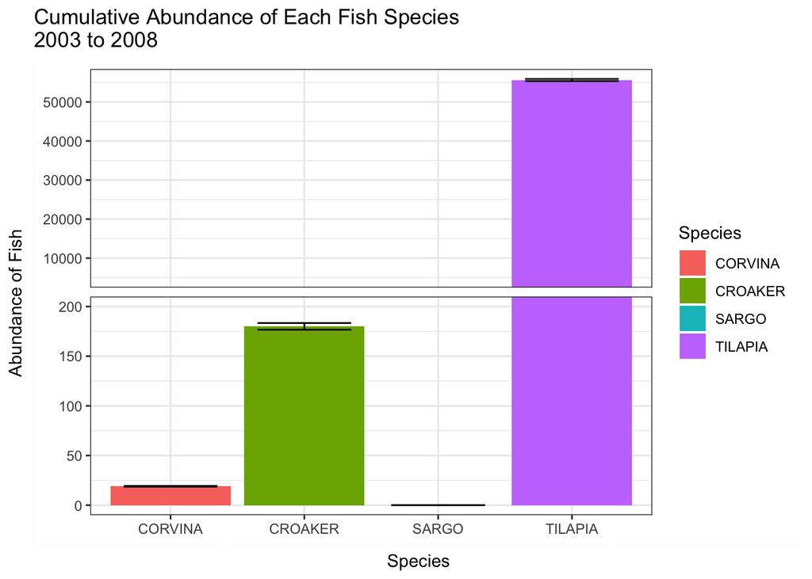

```r
ggplot(Fish_Stats, aes(x = Species, y = total, fill = Species)) +
  geom_col() +
  geom_errorbar(aes(ymax = total + sd, # Adding error bars
                    ymin = total - sd),
                width = 0.70) +
  scale_y_break(c(200, 5000), scales = 1) + # Break in the y-axis
  theme_bw() +
  ggtitle("Cumulative Abundance of Each Fish Species \n2003 to 2008") +
  ylab("Abundance of Fish")
```

There were no sargo fish found during this survey. To better focus on species that were observed the “SARGO” column will be removed for visualization purposes.

```r
long_dat <- long_dat %>%
  filter(!grepl("SARGO", Species))

long_dat
```

```
## # A tibble: 1,227 × 15
##             X       Y OBJECTID PULL_DATE SITE  HABITAT_TY NET_HRS OTHER COMMENTS
##         <dbl>   <dbl>    <dbl> <chr>     <chr> <chr>        <dbl> <chr> <chr>
##  1 -12906353.  3.96e6        1 2008/04/… Nort… Near-shore    24.2 0     <NA>
##  2 -12906353.  3.96e6        1 2008/04/… Nort… Near-shore    24.2 0     <NA>
##  3 -12906353.  3.96e6        1 2008/04/… Nort… Near-shore    24.2 0     <NA>
##  4 -12918979.  3.96e6        2 2008/04/… Whit… Estuarine     24   0     <NA>
##  5 -12918979.  3.96e6        2 2008/04/… Whit… Estuarine     24   0     <NA>
##  6 -12918979.  3.96e6        2 2008/04/… Whit… Estuarine     24   0     <NA>
##  7 -12895737.  3.95e6        3 2008/04/… Bat … Near-shore    23.5 0     <NA>
##  8 -12895737.  3.95e6        3 2008/04/… Bat … Near-shore    23.5 0     <NA>
##  9 -12895737.  3.95e6        3 2008/04/… Bat … Near-shore    23.5 0     <NA>
## 10 -12917368.  3.95e6        4 2008/04/… Dese… Near-shore    24   0     <NA>
## # ℹ 1,217 more rows
## # ℹ 6 more variables: UTM_E <dbl>, UTM_N <dbl>, REPORT <chr>, Date <date>,
## #   Species <chr>, Fish_Abundance <dbl>
```

```r
Fish_Habitat_Stats <- long_dat %>%
  group_by(Species, HABITAT_TY) %>%
  summarise(total = sum(Fish_Abundance),
          mean = round(mean(Fish_Abundance), 3),
          min = min(Fish_Abundance),
          max = max(Fish_Abundance),
          sd = sd(Fish_Abundance))
Fish_Habitat_Stats
```

```
## # A tibble: 9 × 7
## # Groups:   Species [3]
##   Species HABITAT_TY total    mean   min   max      sd
##   <chr>   <chr>      <dbl>   <dbl> <dbl> <dbl>   <dbl>
## 1 CORVINA Estuarine      3   0.029     0     1   0.168
## 2 CORVINA Near-shore    16   0.059     0     5   0.450
## 3 CORVINA Pelagic        0   0         0     0   0
## 4 CROAKER Estuarine     33   0.317     0    10   1.48
## 5 CROAKER Near-shore   147   0.538     0    54   4.01
## 6 CROAKER Pelagic        0   0         0     0   0
## 7 TILAPIA Estuarine  11029 106.        0  1120 239.
## 8 TILAPIA Near-shore 44584 163.        0  2004 302.
## 9 TILAPIA Pelagic        0   0         0     0   0
```

### Looking at abundances of each species of fish among each habitat type

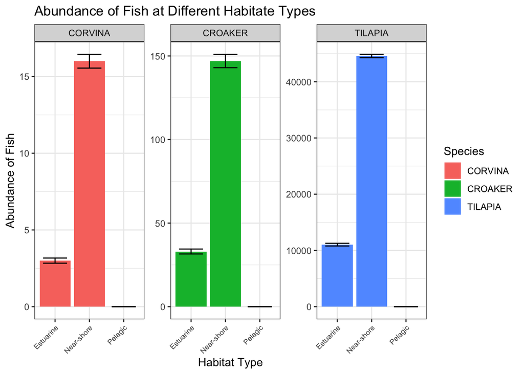

```r
ggplot(Fish_Habitat_Stats, aes(x = HABITAT_TY, y = total, fill = Species)) +
  geom_col() +
  geom_errorbar(aes(ymax = total + sd,
                    ymin = total - sd),
                width = 0.7) +
  ggtitle("Abundance of Fish at Different Habitate Types") +
  ylab("Abundance of Fish") +
  xlab("Habitat Type") +
  theme_bw() +
  theme(axis.text.x = element_text(angle = 45, hjust = 1, vjust = 1, size = 7)) +
  facet_wrap(. ~ Species, scales = "free")
```

No fish were caught from the pelagic habitat type. Most fish of each species were found closest to the Near-shore habitat type.

## Species-based catch-per-unit-effort (CPUE) in units of fish/hr

```r
Species_based_CPUE <- long_dat %>%
  group_by(Species) %>%
  summarise(total_abundance = sum(Fish_Abundance),
            total_hr = sum(NET_HRS),
            CPUE = round(total_abundance/total_hr, 4),
            sd = sd(Fish_Abundance/NET_HRS))

Species_based_CPUE
```

```
## # A tibble: 3 × 5
##   Species total_abundance total_hr   CPUE      sd
##   <chr>             <dbl>    <dbl>  <dbl>   <dbl>
## 1 CORVINA              19   10191. 0.0019  0.0156
## 2 CROAKER             180   10191. 0.0177  0.139
## 3 TILAPIA           55613   10191. 5.46   11.2
```

### Plotting the CPUE for each species of fish

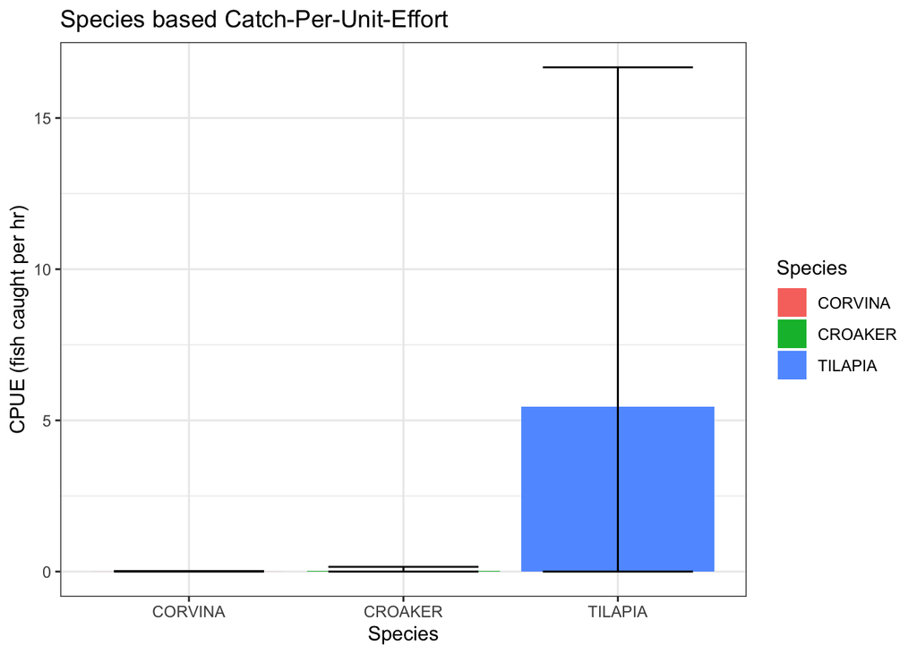

```r
CPUE_Bar_Plot <- ggplot(data = Species_based_CPUE, aes(x = Species, y = CPUE, fill = Species)) +
  geom_col() +
  geom_errorbar(aes(ymax = CPUE + sd,
                    ymin = 0,           # The error bars were limited to y = 0 because there are no negative amounts of fish that are caught
                    width = 0.7)) +
  theme_bw() +
  ggtitle("Species based Catch-Per-Unit-Effort") +
  ylab("CPUE (fish caught per hr)")

CPUE_Bar_Plot
```

There is on average 5.5 tilapia over the course of the entire survey, while the corvinas and croakers were found more elusive.

## **Taking a dive into the population dynamics**

## Making a function for plotting a timeline of fish counts over time

```r
Fish_Time_Line <- function(data, x = Date, y = "fish", title = "Fish Over Time"){

ggplot(data = dat, aes(x = Date, {{y}})) +
  geom_smooth() + # This line shows the overall trend of the data with bounds of certainty
  geom_line(alpha = 0.25) + # This line represents the raw data
  theme_bw() +
  labs(title = title) +
  xlab("Date") +
  ylab("Abundance") +
    theme(
    axis.title.x = element_text(size = 10),
    axis.title.y = element_text(size = 10),
    plot.title = element_text(size = 15))
}
```

## Looking at tilapia, corvina, and croaker population dynamics over time

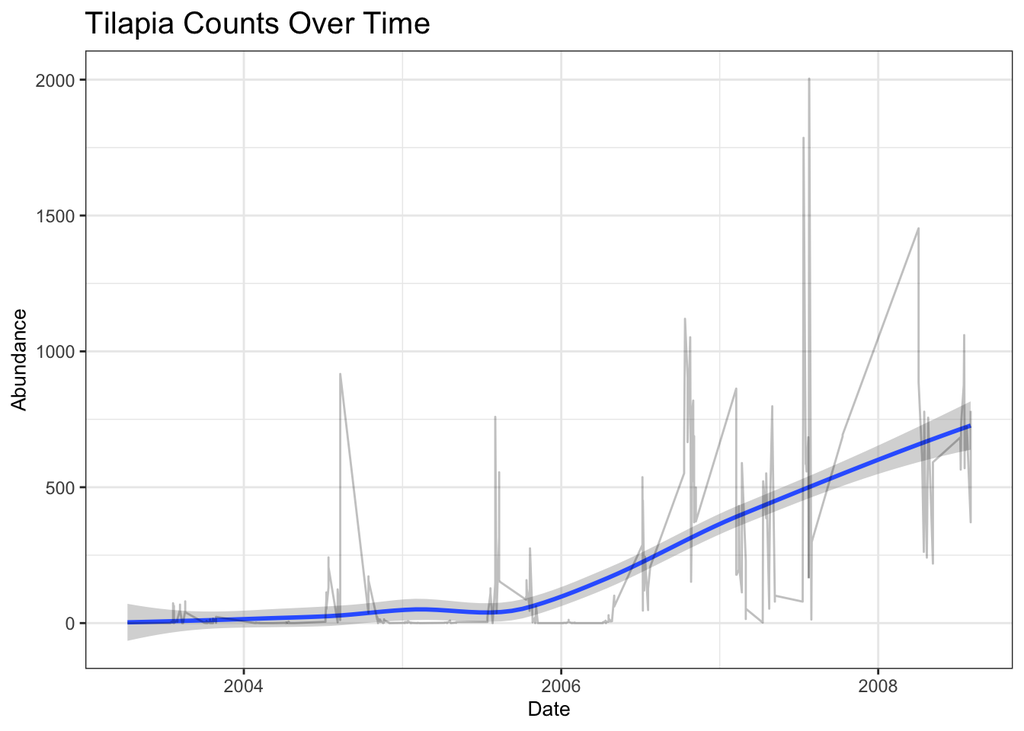

```r
Tilapia_Over_Time <- Fish_Time_Line(data = dat, x = PULL_Date, y = TILAPIA, title = "Tilapia Counts Over Time")

Tilapia_Over_Time
```

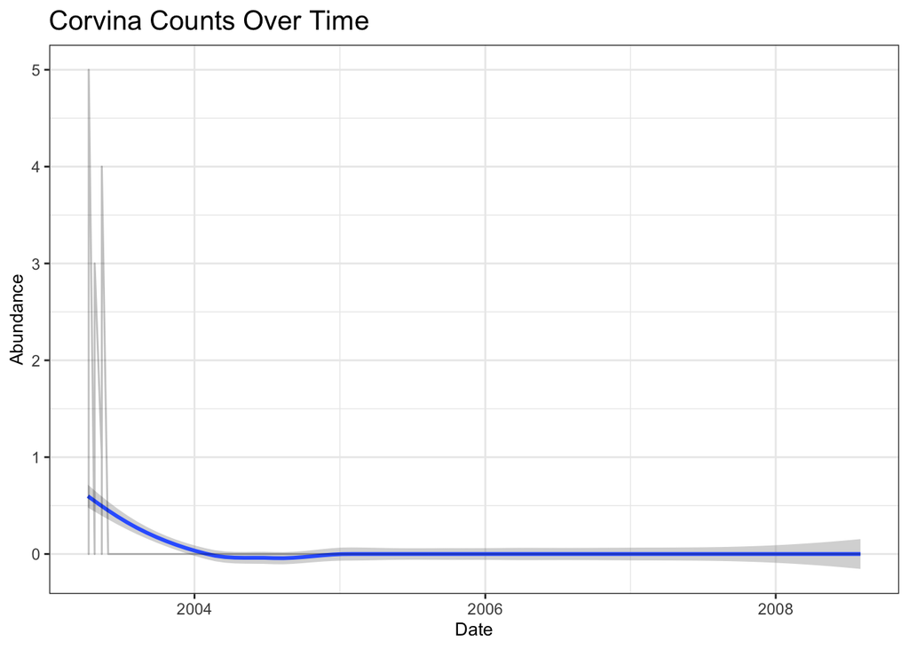

```r
Corvina_Over_Time <- Fish_Time_Line(data = dat, x = Date, y = CORVINA, title = "Corvina Counts Over Time")

Corvina_Over_Time
```

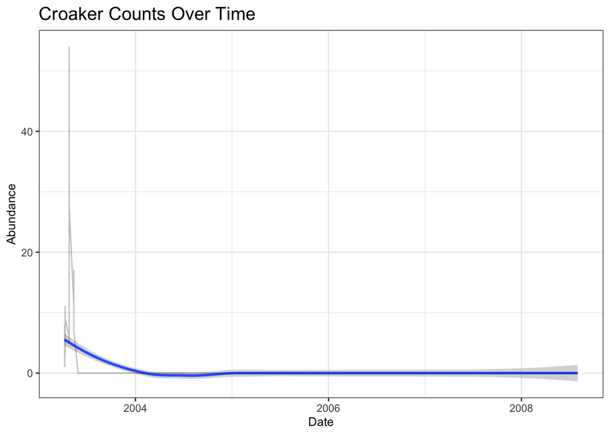

```r
Croaker_Over_Time <- Fish_Time_Line(data = dat, x = Date, y = CROAKER, title = "Croaker Counts Over Time")

Croaker_Over_Time
```

### Plot of all fish species abundance over time

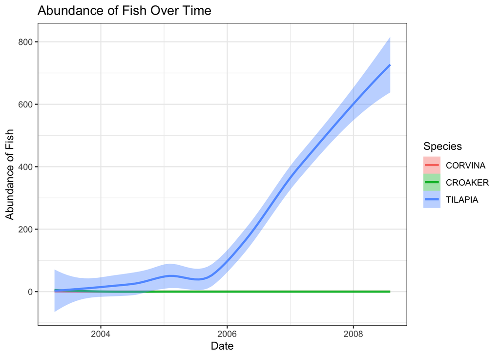

```r
ggplot(long_dat, aes(x = Date, y = Fish_Abundance, color = Species, fill = Species)) +
  geom_smooth() +
  theme_bw() +
  ggtitle("Abundance of Fish Over Time") +
  ylab("Abundance of Fish")
```

The shear number of tilapia drowns out the croaker and corvina.

### Capturing a snapshot comparison of the population dynamics of each species of fish

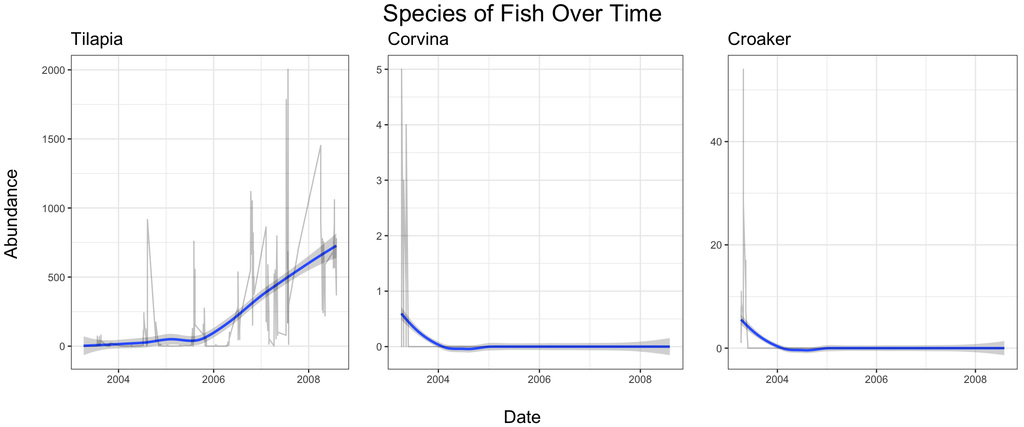

```r
# Creating common titles for the title, x and y axes.

title.common <- textGrob("Species of Fish Over Time",
                   gp=gpar(fontsize=20))

y.common <- textGrob("Abundance",
                   gp=gpar(fontsize=15), rot=90)

x.common <- textGrob("Date",
                   gp=gpar(fontsize=15))

# Arranging the graphs in a grid, removing the y and x axis titles of the original graphs, and replacing them with the common y and x axis titles.
grid.arrange(arrangeGrob(Tilapia_Over_Time + ylab("") + xlab("") + ggtitle("Tilapia"),
                         Corvina_Over_Time + ylab("") + xlab("") + ggtitle("Corvina"),
                         Croaker_Over_Time + ylab("") + xlab("") + ggtitle("Croaker"),
                         ncol = 3,
                         top = title.common,
                         left = y.common,
                         bottom = x.common))
```

Tilapia have shown an increase in abundance over time. Corvina and croaker counts over time are similar in that they both had abundance observed at the beginning of the survey, but shortly after there were little to no observations of either species.

## **Geospatial Observations**

### Survey sites over the Salton Sea

```r
# Load in the shapefiles
shape_data <- st_read("Quarterly_Fishery_Surveys_-_Salton_Sea_[ds428].shp") |>
  st_transform(3857)  # Transform for compatibility with basemap tiles
# Reading the column names of the shapefile
names(shape_data)
```

```
##  [1] "OBJECTID"   "PULL_DATE"  "SITE"       "HABITAT_TY" "NET_HRS"
##  [6] "TILAPIA"    "OTHER"      "CORVINA"    "SARGO"      "CROAKER"
## [11] "COMMENTS"   "UTM_E"      "UTM_N"      "REPORT"     "geometry"
```

```
## Zoom: 10
```

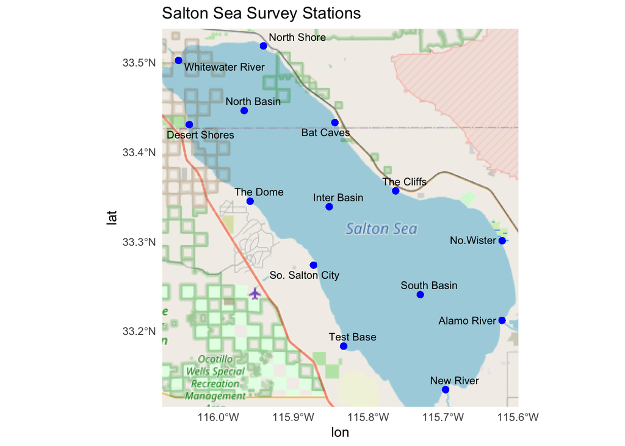

```r
# Extract coordinates and bind to original data
shape_data_coords <- shape_data %>%
  mutate(lon = st_coordinates(geometry)[,1],
         lat = st_coordinates(geometry)[,2])

# Keep the first SITE for each unique location
unique_sites <- shape_data_coords %>%
  group_by(lon, lat) %>%
  slice(1) %>%  # Keep only the first row for each point, to make the names unique
  ungroup() %>%
  mutate(SITE = trimws(gsub("\\(bottom\\) 1", "", SITE))) # Removes "(bottom) 1" and trims any leading/trailing white space. The removal of (bottom) 1 was necessary because there were other site names that indicated the depth at which each site was surveyed and for this map those additional names could clutter the map

# Plot all points, label only one per unique location
ggplot() +
  annotation_map_tile(zoom = 10) +
  geom_sf(data = shape_data, color = "blue", size = 2) +
  geom_text_repel(data = unique_sites, # To add the unique site names to each point
                  aes(x = lon, y = lat, label = SITE),
                  size = 3) +
  coord_sf(crs = st_crs(shape_data)) +
  theme_minimal() +
  labs(title = "Salton Sea Survey Stations")
```

## Looking at the abundances of Taliapia, Covriva, and Croaker at each survey site on a map

### Making a function for graphing the abundances of a specified species of fish

```r
map_spcies_abundance <- function(data = shape_data_coords, fish_species = "TILAPIA", name = "fish_species Abundance", title = "Species of Fish Abundance at Salton Sea Sampling Stations"){

  survey_sites <- shape_data_coords %>%
  group_by(lon, lat) %>%
  summarise(fish_species = sum({{fish_species}}, na.rm = TRUE),
            geometry = first(geometry)) %>%
  st_as_sf(crs = st_crs(shape_data))

ggplot() +
  annotation_map_tile(zoom = 10) +
  geom_sf(data = survey_sites, aes(color = fish_species), size = 3) +
  geom_text_repel(data = unique_sites, # To add the unique site names to each point
                  aes(x = lon, y = lat, label = SITE),
                  size = 3) +
  coord_sf(crs = st_crs(shape_data)) + # coord_sf() ensures that all layers use a common CRS.
  scale_color_viridis_c(option = "C", name = name) +
  theme_minimal() +
  labs(title = title)
}
```

```r
tilapia_abundance_map <- map_spcies_abundance(data = shape_data_coords, fish_species = TILAPIA, name = "Tilapia Abundance", title = "Tilapia Abundance at Salton Sea Sampling Stations")
```

[output not shown]

```r
tilapia_abundance_map
```

```
## Zoom: 10
```

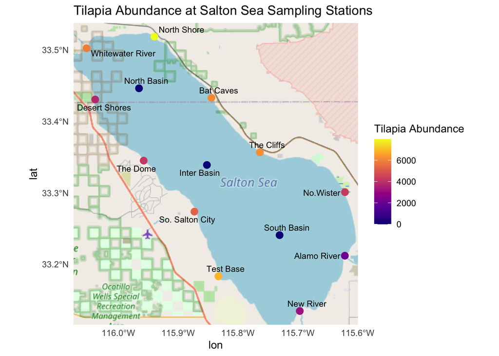

North Shore contained most of the tilapia observed and all of the basin locations contained the lowest counts.

```r
corvina_abundance_map <- map_spcies_abundance(data = shape_data_coords, fish_species = CORVINA, name = "Corvina Abundance", title = "Corvina Abundance at Salton Sea Sampling Stations")
```

[output not shown]

```r
corvina_abundance_map
```

```
## Zoom: 10
```

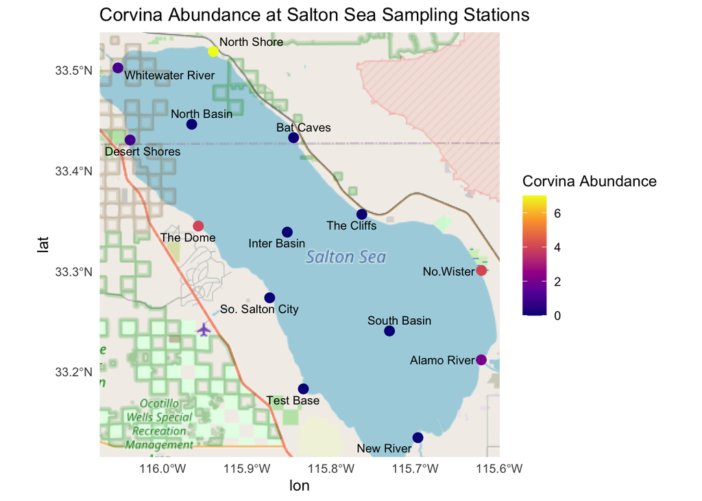

North Shore is also the site with the most abundance of another fish - corvina

```r
croaker_abundance_map <- map_spcies_abundance(data = shape_data_coords, fish_species = CROAKER, name = "Croaker Abundance", title = "Croaker Abundance at Salton Sea Sampling Stations")
```

[output not shown]

```r
croaker_abundance_map
```

```
## Zoom: 10
```

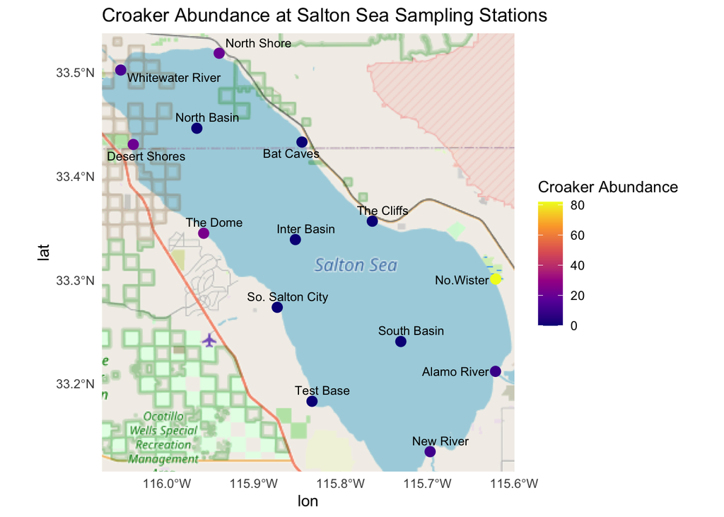

North Wister has the largest abundance of croaker found during the course of the study.

## Abundances of each fish species at each survay site

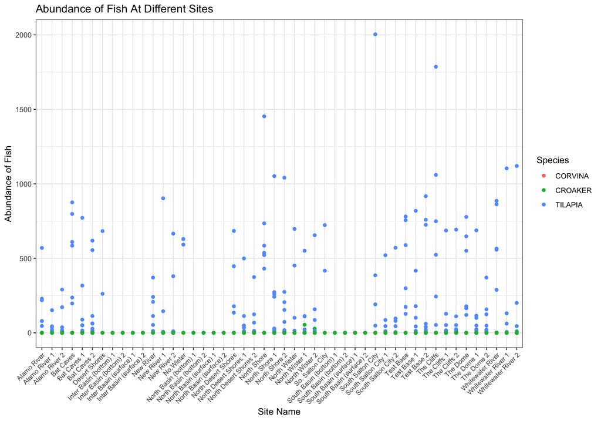

```r
ggplot(long_dat, aes(x = SITE, y = Fish_Abundance, color = Species)) +
  geom_point() +
  theme_bw() +
  ggtitle("Abundance of Fish At Different Sites") +
  ylab("Abundance of Fish") +
  xlab("Site Name") +
  theme(axis.text.x = element_text(angle = 45, hjust = 1, vjust = 1, size = 8))
```

## Conclusion

The Salton Sea, a terminal lake facing ecological decline, is currently the focus of active conservation efforts aimed at restoring its health and biodiversity. This analysis reveals distinct trends among the four sportfish species studied. Tilapia populations have shown substantial growth over time, whereas both croaker and corvina experienced rapid declines shortly after monitoring began. Sargos were not observed during the study period and were therefore excluded from the analysis.

Spatially, fish abundance was highest in near-shore habitats, with the central basin yielding the lowest catch rates across all species — emphasizing the importance of shoreline environments for sustaining fish populations in the Sea.

## References

```
1.  California Department of Water Resources. Salton Sea Unit. https://water.ca.gov/saltonsea/ (accessed 29 Mar. 2025).

2.  California Department of Fish and Wildlife. Background Information on the Salton Sea. https://wildlife.ca.gov/Regions/6/Salton-Sea-Program/Background (accessed 29 Mar. 2025).

3.  California Department of Fish and Wildlife. Salton Sea Management Efforts. https://wildlife.ca.gov/Regions/6/Salton-Sea-Program/Management-Efforts (accessed 29 Mar. 2025).

4.  California Natural Resources Agency. Quarterly Fishery Surveys - Salton Sea [ds428]. https://data.cnra.ca.gov/dataset/quarterly-fishery-surveys-salton-sea-ds428 (accessed 29 Mar. 2025).
```